# Fixing Employee Happiness at TechTrend Innovations - Assignment 02

You should complete this Jupyter Notebook with your answers. You may need to write code or add explanatory notes.

dataset link: https://www.kaggle.com/datasets/lainguyn123/employee-survey/data

```python
# Importing packages
import pandas as pd
import numpy as np
import seaborn as sns
import matplotlib.pyplot as plt
```

### Getting the Dataset in Colab

To download the dataset, you’ll need a Kaggle API key. If you’re using Google Colab and don’t have one yet, follow these steps:

1. Go to Kaggle.com, sign in, and create an API key under your account settings.
2. Download the `kaggle.json` file.
3. Run the code snippet below, then upload your `kaggle.json` file when prompted.

Once that’s done, you can download the dataset with the Kaggle API

```python
from google.colab import files

files.upload()
!mkdir -p ~/.kaggle
!cp kaggle.json ~/.kaggle/
!chmod 600 ~/.kaggle/kaggle.json
```

Upload widget is only available when the cell has been executed in the current browser session. Please rerun this cell to enable.

```
Saving kaggle.json to kaggle.json
```

```python
import os
import zipfile

# Install Kaggle
%pip install kaggle

# Create a folder to store the dataset
folder_name = 'EmployeeData'
os.makedirs(folder_name, exist_ok=True)

# Download dataset from Kaggle
!kaggle datasets download -d lainguyn123/employee-survey -p {folder_name}

# Unzip the dataset into the folder
zip_path = f"{folder_name}/employee-survey.zip"
with zipfile.ZipFile(zip_path, 'r') as zip_ref:
    zip_ref.extractall(folder_name)
```

```
Dataset URL: https://www.kaggle.com/datasets/lainguyn123/employee-survey
License(s): other
```

```python
# Load and print head of the dataset
df = pd.read_csv(f"./{folder_name}/employee_survey.csv")
df.head()
```

|  | EmpID | Gender | Age | MaritalStatus | JobLevel | Experience | Dept | EmpType | WLB | WorkEnv | ... | SleepHours | CommuteMode | CommuteDistance | NumCompanies | TeamSize | NumReports | EduLevel | haveOT | TrainingHoursPerYear | JobSatisfaction |
| --- | --- | --- | --- | --- | --- | --- | --- | --- | --- | --- | --- | --- | --- | --- | --- | --- | --- | --- | --- | --- | --- |
| 0 | 6 | Male | 32 | Married | Mid | 7 | IT | Full-Time | 1 | 1 | ... | 7.6 | Car | 20 | 3 | 12 | 0 | Bachelor | True | 33.5 | 5 |
| 1 | 11 | Female | 34 | Married | Mid | 12 | Finance | Full-Time | 1 | 1 | ... | 7.9 | Car | 15 | 4 | 11 | 0 | Bachelor | False | 36.0 | 5 |
| 2 | 33 | Female | 23 | Single | Intern/Fresher | 1 | Marketing | Full-Time | 2 | 4 | ... | 6.5 | Motorbike | 17 | 0 | 30 | 0 | Bachelor | True | 10.5 | 5 |
| 3 | 20 | Female | 29 | Married | Junior | 6 | IT | Contract | 2 | 2 | ... | 7.5 | Public Transport | 13 | 2 | 9 | 0 | Bachelor | True | 23.0 | 5 |
| 4 | 28 | Other | 23 | Single | Junior | 1 | Sales | Part-Time | 3 | 1 | ... | 4.9 | Car | 20 | 0 | 7 | 0 | Bachelor | False | 20.5 | 5 |

5 rows × 23 columns

## Background

Imagine a grumpy CEO, MR. Bluffington, who’s obsessed with making it look like his employees are thrilled to be at work. To pull off this illusion, he hires a sneaky hacker group called Hack&Cheese to break into company records—including those at TechTrend Innovations—and boost the JobSatisfaction scores (1–5) to make it seem like everyone’s loving their job!

This messes up important tools people rely on: performance trackers used for promotions, health insurers calculating coverage costs, and job platforms helping folks find the right work. These systems are now totally confused… until a new survey rolls in.

But wait—you have a secret copy of TechTrend’s original, unaltered data from before the hack!

Let’s expose the truth and stop Bluffington’s data deception!

## Task 1: Fixing TechTrend’s Data to Beat General Victor Smirkov’s Hack

Mr. Bluffingtion’s hackers messed up TechTrend’s happiness numbers, but your real data can fix it.

- Make a new target, `SatisfactionLevel`, where `JobSatisfaction` 3-5 is "Satisfied" and 1-2 is "Dissatisfied". Then remove `JobSatisfaction`—it’s fake outside, and we’re making it new.
- Clean the rest: turn words like `Gender` or `Dept` into numbers, adjust numbers like `Age` or `HoursWorkload`, and fill any blanks.

```python
# Write your answer here:
print(list(df.columns))
df.head()
#df["Workload"].head(20)
```

```
['EmpID', 'Gender', 'Age', 'MaritalStatus', 'JobLevel', 'Experience', 'Dept', 'EmpType', 'WLB', 'WorkEnv', 'PhysicalActivityHours', 'Workload', 'Stress', 'SleepHours', 'CommuteMode', 'CommuteDistance', 'NumCompanies', 'TeamSize', 'NumReports', 'EduLevel', 'haveOT', 'TrainingHoursPerYear', 'JobSatisf…
```

|  | EmpID | Gender | Age | MaritalStatus | JobLevel | Experience | Dept | EmpType | WLB | WorkEnv | ... | SleepHours | CommuteMode | CommuteDistance | NumCompanies | TeamSize | NumReports | EduLevel | haveOT | TrainingHoursPerYear | JobSatisfaction |
| --- | --- | --- | --- | --- | --- | --- | --- | --- | --- | --- | --- | --- | --- | --- | --- | --- | --- | --- | --- | --- | --- |
| 0 | 6 | Male | 32 | Married | Mid | 7 | IT | Full-Time | 1 | 1 | ... | 7.6 | Car | 20 | 3 | 12 | 0 | Bachelor | True | 33.5 | 5 |
| 1 | 11 | Female | 34 | Married | Mid | 12 | Finance | Full-Time | 1 | 1 | ... | 7.9 | Car | 15 | 4 | 11 | 0 | Bachelor | False | 36.0 | 5 |
| 2 | 33 | Female | 23 | Single | Intern/Fresher | 1 | Marketing | Full-Time | 2 | 4 | ... | 6.5 | Motorbike | 17 | 0 | 30 | 0 | Bachelor | True | 10.5 | 5 |
| 3 | 20 | Female | 29 | Married | Junior | 6 | IT | Contract | 2 | 2 | ... | 7.5 | Public Transport | 13 | 2 | 9 | 0 | Bachelor | True | 23.0 | 5 |
| 4 | 28 | Other | 23 | Single | Junior | 1 | Sales | Part-Time | 3 | 1 | ... | 4.9 | Car | 20 | 0 | 7 | 0 | Bachelor | False | 20.5 | 5 |

5 rows × 23 columns

```python
from sklearn.preprocessing import LabelEncoder
df["SatisfactionLevel"] = df["JobSatisfaction"].apply(lambda s: "Satisfied" if s>2 else "Dissatisfied")
df.drop(columns=["JobSatisfaction"],inplace = True)
```

```python
nums = df.select_dtypes(include='number').columns
print(df[nums].isnull().sum())
```

```
EmpID                    0
Age                      0
Experience               0
WLB                      0
WorkEnv                  0
PhysicalActivityHours    0
Workload                 0
Stress                   0
SleepHours               0
CommuteDistance          0
NumCompanies             0
TeamSize                 0
NumReports               0
TrainingHoursPerYear     0
dtype: int64
```

🗣 It appears that there are no missing values, and all entries in the dataset are complete. Therefore, to verify data accuracy, we look for potential outliers.

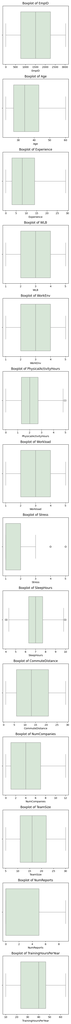

```python
import seaborn as sns
import matplotlib.pyplot as plt
plt.figure(figsize=(4, 4 * len(nums)))
for i, col in enumerate(nums, 1):
    plt.subplot(len(nums), 1, i)
    sns.boxplot(x=df[col], color='#D5E8D4')
    plt.title(f'Boxplot of {col}')
    plt.tight_layout()

plt.show()
```

🗣 Boxplots showed that the columns **PhysicalActivityHours**, **SleepHours**, and **Stress** contain outliers, as their values fall outside the IQR range. We now inspect these values more closely to assess whether they are reasonable or should be removed as anomalies.

```python
outlier_cols = ['PhysicalActivityHours', 'SleepHours', 'Stress']
df_check = df.copy()
for col in outlier_cols:
    Q1 = df_check[col].quantile(0.25)
    Q3 = df_check[col].quantile(0.75)
    IQR = Q3 - Q1
    lower = Q1 - 1.5 * IQR
    upper = Q3 + 1.5 * IQR
    print(f"\nOutliers in '{col}':")
    outliers = df_check[(df_check[col] < lower) | (df_check[col] > upper)]
    print(outliers[[col]])
    print(f"\nmedian of {col}: '{df_check[col].median()}'")
```

```
Outliers in 'PhysicalActivityHours':
      PhysicalActivityHours
1200                    4.9
1948                    5.0
2228                    5.0
2274                    4.9

median of PhysicalActivityHours: '2.0'

Outliers in 'SleepHours':
      SleepHours
21          10.0
167          4.0
358          4.0
1192         4.0
1196         4.0
1820        10.0
2183         9.9
2545         4.1
2584         4.0
2603         9.9
2620        10.0
2696         4.1
2715         4.1
2948        10.0

median of SleepHours: '7.0'

Outliers in 'Stress':
      Stress
2          4
112        5
124        4
159        4
171        4
...      ...
3003       5
3004       5
3017       4
3019       5
3024       5

[255 rows x 1 columns]

median of Stress: '1.0'
```

🗣 Although a number of values in the **PhysicalActivityHours**, **SleepHours**, and **Stress** columns were identified as outliers based on the IQR method, our inspection showed that none of them appear unrealistic or erroneous. Therefore, we chose **not to remove** these outliers, as they seem to reflect valid variability in the data.

-- Now that we have thoroughly reviewed and cleaned the numeric columns, we can converting qualitative variables into numerical indicator variables suitable for modeling.

```python
from sklearn.preprocessing import LabelEncoder
df2 = pd.DataFrame(index=df.index)
cat_cols = df.select_dtypes(include='object').columns
for col in nums:
  df2[col] = df[col]
for col in cat_cols:
    df2[col] = LabelEncoder().fit_transform(df[col])
```

```python
df2.head()
```

|  | EmpID | Age | Experience | WLB | WorkEnv | PhysicalActivityHours | Workload | Stress | SleepHours | CommuteDistance | ... | NumReports | TrainingHoursPerYear | Gender | MaritalStatus | JobLevel | Dept | EmpType | CommuteMode | EduLevel | SatisfactionLevel |
| --- | --- | --- | --- | --- | --- | --- | --- | --- | --- | --- | --- | --- | --- | --- | --- | --- | --- | --- | --- | --- | --- |
| 0 | 6 | 32 | 7 | 1 | 1 | 2.5 | 2 | 1 | 7.6 | 20 | ... | 0 | 33.5 | 1 | 1 | 3 | 3 | 1 | 1 | 0 | 1 |
| 1 | 11 | 34 | 12 | 1 | 1 | 1.8 | 2 | 2 | 7.9 | 15 | ... | 0 | 36.0 | 0 | 1 | 3 | 1 | 1 | 1 | 0 | 1 |
| 2 | 33 | 23 | 1 | 2 | 4 | 2.1 | 5 | 4 | 6.5 | 17 | ... | 0 | 10.5 | 0 | 2 | 0 | 5 | 1 | 2 | 0 | 1 |
| 3 | 20 | 29 | 6 | 2 | 2 | 1.9 | 3 | 1 | 7.5 | 13 | ... | 0 | 23.0 | 0 | 1 | 1 | 3 | 0 | 3 | 0 | 1 |
| 4 | 28 | 23 | 1 | 3 | 1 | 3.7 | 2 | 1 | 4.9 | 20 | ... | 0 | 20.5 | 2 | 2 | 1 | 7 | 2 | 1 | 0 | 1 |

5 rows × 22 columns

## Task 2: Showing the Real Satisfaction Split at TechTrend

The CEO says all workers are happy, but your data might prove him wrong. Let’s look.

- Count how many are Satisfied vs. Dissatisfied in `SatisfactionLevel` and show the numbers.
- Make a picture (like a bar chart) to show if more are Satisfied or not.

```
SatisfactionLevel
Satisfied       2331
Dissatisfied     694
Name: count, dtype: int64
```

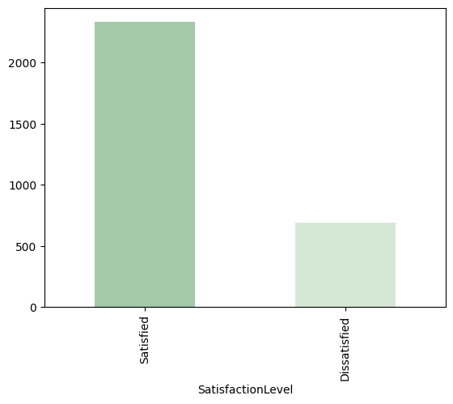

```python
# Write your answer here:
counts = df["SatisfactionLevel"].value_counts()
print(counts)
counts.plot(kind='bar', color=['#A3C9A8', '#D5E8D4'])
plt.show()
```

🗣 The analysis shows that while most employees are satisfied, nearly 25% are dissatisfied. This indicates that the CEO’s statement was overly optimistic and not entirely accurate.

## Task 3: Digging Up What Really Shapes Satisfaction at TechTrend

TechTrend's tools need to know what changes happiness to work right. Let’s check it out.

- Guess which things—like `haveOT`, `WLB`, or `HoursWorkload`—might affect `SatisfactionLevel`.
- Explore how these factors relate to happiness, for example, using statistical methods, charts, or other analyses.

*In a markdown cell, tell your guesses and what the pictures show about TechTrend’s true workers.*

🗣 Based on the available variables, we hypothesize that SleepHours, Work-Life Balance (WLB), perceived stress level, TeamSize, Workload, and having Overtime (haveOT) may have a significant impact on employee satisfaction.

```python
# Write your answer here:
import statsmodels.api as sm

guessed_columns = ['SleepHours', 'WLB', 'Stress', 'TeamSize', 'Workload', 'haveOT']
y = df['SatisfactionLevel'].replace({'Satisfied': 1, 'Dissatisfied': 0}).astype(float)

for col in guessed_columns:
    X_raw = df[[col]]
    X = X_raw if pd.api.types.is_numeric_dtype(X_raw[col]) else pd.get_dummies(X_raw, drop_first=True)
    X = X.loc[:, X.apply(lambda c: c.nunique() > 1)]
    if X.shape[1] == 0: continue
    X = sm.add_constant(X).astype(float)
    X = X.dropna()
    y_clean = y.loc[X.index]
    if X.shape[0] <= X.shape[1]: continue

    try:
        model = sm.Logit(y_clean, X).fit(disp=0)
        print(f"\n🔹 Summary for: {col}")
        print(model.summary())
    except:
        continue
```

```
🔹 Summary for: SleepHours
                           Logit Regression Results
==============================================================================
Dep. Variable:      SatisfactionLevel   No. Observations:                 3025
Model:                          Logit   Df Residuals:                     3023
Method:                           MLE   Df Model:                            1
Date:                Tue, 13 May 2025   Pseudo R-squ.:                 0.01783
Time:                        04:41:33   Log-Likelihood:                -1600.1
converged:                       True   LL-Null:                       -1629.2
Covariance Type:            nonrobust   LLR p-value:                 2.497e-14
==============================================================================
                 coef    std err          z      P>|z|      [0.025      0.975]
------------------------------------------------------------------------------
const         -1.1062      0.308     -3.586      0.000      -1.711      -0.502
SleepHours     0.3351      0.045      7.496      0.000       0.247       0.423
==============================================================================

🔹 Summary for: WLB
                           Logit Regression Results
==============================================================================
Dep. Variable:      SatisfactionLevel   No. Observations:                 3025
Model:                          Logit   Df Residuals:                     3023
Method:                           MLE   Df Model:                            1
Date:                Tue, 13 May 2025   Pseudo R-squ.:                 0.03444
Time:                        04:41:33   Log-Likelihood:                -1573.1
converged:                       True   LL-Null:                       -1629.2
Covariance Type:            nonrobust   LLR p-value:                 3.185e-26
==============================================================================
                 coef    std err          z      P>|z|      [0.025      0.975]
------------------------------------------------------------------------------
const          0.2810      0.095      2.952      0.003       0.094       0.468
WLB            0.3231      0.031     10.352      0.000       0.262       0.384
==============================================================================

🔹 Summary for: Stress
                           Logit Regression Results
==============================================================================
Dep. Variable:      SatisfactionLevel   No. Observations:                 3025
Model:                          Logit   Df Residuals:                     3023
Method:                           MLE   Df Model:                            1
```

[output cut: 46 more lines]

```
                           Logit Regression Results
==============================================================================
Dep. Variable:      SatisfactionLevel   No. Observations:                 3025
Model:                          Logit   Df Residuals:                     3023
Method:                           MLE   Df Model:                            1
Date:                Tue, 13 May 2025   Pseudo R-squ.:                0.009466
Time:                        04:41:33   Log-Likelihood:                -1613.8
converged:                       True   LL-Null:                       -1629.2
Covariance Type:            nonrobust   LLR p-value:                 2.794e-08
==============================================================================
                 coef    std err          z      P>|z|      [0.025      0.975]
------------------------------------------------------------------------------
const          1.3827      0.055     25.306      0.000       1.276       1.490
haveOT        -0.5057      0.090     -5.607      0.000      -0.682      -0.329
==============================================================================
```

🗣 Logistic regression analysis shows that several key factors significantly impact employee satisfaction at TechTrend. Better work-life balance (WLB) and adequate sleep (SleepHours) are strongly associated with higher satisfaction. Conversely, high workload (Workload), elevated stress levels (Stress), and frequent overtime (haveOT) are linked to decreased satisfaction.

Notably, the number of team members (TeamSize) was not found to be a statistically significant predictor (p ≈ 0.8), indicating that team size alone may not play a direct role in shaping employee satisfaction within this context.

## Task 4: Nailing the Big Clues to Stop General Victor Smirkov

Mr. Bluffington’s hack hid what’s real, but TechTrend needs the top reasons for happiness to fix its tools. Let’s find them.

- Choose a way (like Recursive Feature Elimination or Correlation Thresholding) to pick the best features for guessing `SatisfactionLevel`.
- List your top features and say why your way works for TechTrend.

*In a markdown cell, tell how these features can help TechTrend’s tools win.*

```python
# Write your answer here:
from sklearn.linear_model import LogisticRegression
from sklearn.preprocessing import StandardScaler
X_lasso = pd.get_dummies(df.drop(columns=['SatisfactionLevel', 'EmpID', 'Gender', 'Dept']), drop_first=True)
y_lasso = y.loc[X_lasso.index]
X_scaled = StandardScaler().fit_transform(X_lasso)
lasso_strict = LogisticRegression(penalty='l1', solver='saga', C=0.01, max_iter=5000, random_state=42)
lasso_strict.fit(X_scaled, y_lasso)
coef = pd.Series(lasso_strict.coef_[0], index=X_lasso.columns)
selected_strict = coef[coef != 0].sort_values(ascending=False)

print("Strictly Selected by LASSO (C = 0.01):")
print(selected_strict)
```

```
Strictly Selected by LASSO (C = 0.01):
EduLevel_Master    0.278029
WLB                0.271388
WorkEnv            0.167051
SleepHours         0.164193
haveOT            -0.055063
Stress            -0.207062
Workload          -0.241144
dtype: float64
```

🗣 LASSO works by applying strong regularization to the model coefficients, effectively shrinking the weights of less informative features to zero while preserving the most predictive variables. In this analysis, we used a strict penalty level (C = 0.01) to enforce selective and meaningful feature reduction. The model identified key variables such as EduLevel_Master, WLB, WorkEnv, SleepHours, haveOT, Stress, and Workload as the most influential predictors of employee satisfaction. Using LASSO offers several advantages for TechTrend: it simplifies the model by removing irrelevant or redundant predictors, improves interpretability, and helps analysts focus on the features that truly matter. In addition, by reducing the risk of overfitting, LASSO enhances model generalizability and builds a more reliable foundation for the company’s decision-making tools.

## Task 5: Train a Model to Unmask the True Satisfaction

Mr. Bluffington’s fake numbers won’t fool us! Use your Task 4 features to predict the real `SatisfactionLevel` (Satisfied or Dissatisfied). Pick a classifier—like Naive Bayes or any you prefer—and tweak at least one hyperparameter (e.g., smoothing) to make it sharp. Train it using cross-validation (e.g., k-fold) to ensure it’s tough enough to expose the truth.

```python
# Write your answer here:
from sklearn.naive_bayes import BernoulliNB
from sklearn.model_selection import train_test_split
from sklearn.preprocessing import StandardScaler
from sklearn.metrics import accuracy_score
from sklearn.metrics import classification_report, precision_recall_fscore_support

selected_features = ['EduLevel', 'WLB', 'WorkEnv', 'SleepHours', 'haveOT', 'Stress', 'Workload']
X = df[selected_features].copy()
X = pd.get_dummies(X, drop_first=True)
y = df['SatisfactionLevel'].replace({'Satisfied': 1, 'Dissatisfied': 0}).astype(int)
y = y.loc[X.index]

# Split the dataset to train and test sets (80/20)
X_train, X_test, y_train, y_test = train_test_split(X, y, test_size=0.2, random_state=42)

# Standardize features to ensure balanced model behavior and improve convergence
scaler = StandardScaler()
X_train_scaled = scaler.fit_transform(X_train)
X_test_scaled = scaler.transform(X_test)

# Train a Naive Bayes classifier with Laplace smoothing to handle binary input features
model = BernoulliNB(alpha=0.5)
model.fit(X_train_scaled, y_train)

# Predict satisfaction levels on the test set and evaluate the model’s accuracy
y_pred = model.predict(X_test_scaled)
accuracy = accuracy_score(y_test, y_pred)
print("Accuracy:", accuracy)
report = classification_report(y_test, y_pred, target_names=['Dissatisfied', 'Satisfied'])
print(report)
```

```
Accuracy: 0.7900826446280992
              precision    recall  f1-score   support

Dissatisfied       0.66      0.26      0.37       145
   Satisfied       0.80      0.96      0.87       460

    accuracy                           0.79       605
   macro avg       0.73      0.61      0.62       605
weighted avg       0.77      0.79      0.75       605
```

## Task 6: Reveal the Real Balance to Train Smarter

Fake numbers hid the truth, but your secret data doesn’t lie. First, check the real split between Satisfied and Dissatisfied workers to see how things actually were before the hack. Then, use what you find to train your model fairly—apply techniques (like oversampling or using class weights) to handle any imbalance and make sure it predicts the true `SatisfactionLevel` accurately.

```python
# Write your answer here:
print(df['SatisfactionLevel'].value_counts(normalize=True))
```

```
SatisfactionLevel
Satisfied       0.770579
Dissatisfied    0.229421
Name: proportion, dtype: float64
```

🗣 To ensure fair training and avoid bias toward the majority class, we apply **oversampling** to balance the dataset. In our case, the number of Dissatisfied employees is significantly lower than Satisfied, which can cause the model to favor the dominant class during learning. We use **Random Oversampling** to increase the number of samples in the minority class by duplicating them until both classes are equally represented. This helps the model learn to identify patterns from both classes more accurately and prevents misleadingly high accuracy due to imbalance.

```python
from imblearn.over_sampling import RandomOverSampler

# Apply Random Oversampling on training data from Task 5
ros = RandomOverSampler(random_state=42)
X_train_over, y_train_over = ros.fit_resample(X_train, y_train)
X_train_over_scaled = scaler.fit_transform(X_train_over)
X_test_scaled = scaler.transform(X_test)  # X_test still the same

model_oversampled = BernoulliNB(alpha=0.5)
model_oversampled.fit(X_train_over_scaled, y_train_over)

y_pred_over = model_oversampled.predict(X_test_scaled)
print("Accuracy after Oversampling:", accuracy_score(y_test, y_pred_over))
print("Accuracy before Oversampling:", accuracy)
```

```
Accuracy after Oversampling: 0.6578512396694215
Accuracy before Oversampling: 0.7900826446280992
```

## Task 7: Evaluate the Model and Analyze the Truth to Fix TechTrend’s Tools

Time to prove Mr. Bluffington’s fakeout fails! Test your classifier with metrics like precision, recall, and F1-score to see how well it identifies true Satisfied and Dissatisfied workers. Then, analyze the results of these metrics to understand how your model exposes the real `SatisfactionLevel`, helping tools like job sites and performance trackers get back on track with the truth.

```python
# Write your answer here:
from sklearn.metrics import classification_report, precision_recall_fscore_support
print("Report before and after oversampling")
print(report)
print(classification_report(y_test, y_pred_over, target_names=['Dissatisfied', 'Satisfied']))
```

```
Report before and after oversampling
              precision    recall  f1-score   support

Dissatisfied       0.66      0.26      0.37       145
   Satisfied       0.80      0.96      0.87       460

    accuracy                           0.79       605
   macro avg       0.73      0.61      0.62       605
weighted avg       0.77      0.79      0.75       605

              precision    recall  f1-score   support

Dissatisfied       0.39      0.76      0.52       145
   Satisfied       0.89      0.63      0.74       460

    accuracy                           0.66       605
   macro avg       0.64      0.69      0.63       605
weighted avg       0.77      0.66      0.68       605
```

🗣 Final Evaluation Based on Precision, Recall, and F1-Score